Skip to content

[ALI SOLEIMANI.](https://alisoleimani.de/)

UNIPER · DÜSSELDORF · REQ 89638

# Engineering insight. Commercial analysis.

Product Structuring & Pricing  
Working Student application

I am Ali Soleimani, an International Management master's student and Strategic Sourcing lecturer with an engineering background and 10 years in procurement and project coordination. I want to bring structured analysis, digital workflow experience and international collaboration to Uniper's Commercial Power team while developing expertise in renewable power valuation.

Explore my fit ↗[LinkedIn ↗](https://www.linkedin.com/in/alisoleimani-de/)

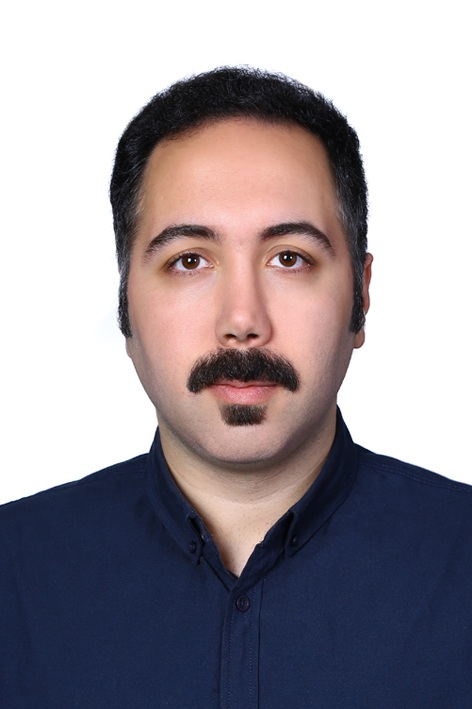

Cologne, Germany · English C1 · German A2

CURRENT STUDIES**M.A. International Management**

Hochschule Fresenius · Project Management

CURRENT GPA**1.2**

CORE TOOL**Advanced Excel**

HOW I WOULD CONTRIBUTE

## Clear information. Consistent follow-through.

01 / ANALYSIS & EXCEL

### Prepare clear analytical inputs

Advanced Excel, commercial offer comparison and management reporting provide a practical foundation for preparing and checking analytical information. I have also taught Excel to engineering students.

02 / ENGINEERING & ECONOMICS

### Connect simulation with commercial questions

Chemical Engineering studies in Simulation, Modeling and Control, research and economic assessment of refrigeration systems underpin my quantitative approach. I want to develop this foundation in renewable power valuation and market analysis.

03 / INTERNATIONAL TEAM SUPPORT

### Keep people and actions aligned

International project coordination and teaching help me explain commercial information, prepare presentations and follow up on open questions. I would bring these habits to collaboration with analysts and commercial, risk and IT stakeholders.

RELEVANT EXPERIENCE

## A commercial and analytical foundation.

OCT 2026 - PRESENT

### Lecturer - Strategic Sourcing

**Hochschule Fresenius · Cologne**

Teach MSc students using practical procurement cases, supplier evaluation and cost and risk considerations. Prepare structured exercises and explain commercial concepts clearly.

DEC 2017 - FEB 2026

### Project Manager & Executive Coordinator

**Petro Sanat Lidoma · Tehran**

Prepared management reports, coordinated technical and commercial teams, tracked milestones and open issues, and followed up with 30+ international suppliers. Improved procurement workflows and digital documentation.

JUN 2016 - NOV 2017

### Procurement Specialist

**Petro Sanat Lidoma · Tehran**

Compared commercial and technical offers and coordinated pricing, documentation and delivery follow-up with international suppliers.

JAN - MAY 2016

### Research Assistant

**Iran University of Science and Technology · Tehran**

Supported simulation and economic evaluation of refrigeration systems and delivered Microsoft Excel training to engineering students.

SEP - DEC 2026 · ONGOING COLLABORATION

### Digital Workflow & AI Integration

**Hochschule Fresenius & KUKUK Ingenieure**

Contribute to workflow design, test planning and evaluation of digital tools; maintain documentation and track deliverables with academic and industry stakeholders.

EDUCATION & TOOLS

## Engineering depth. Business perspective.

**M.A. International Management** · Hochschule Fresenius · Mar 2026 - Expected Feb 2028 · Current GPA 1.2  
Project Management focus; Data Analysis for Decision Making and International Business.

**M.Sc. Chemical Engineering** · IUST · 2015 - 2018 · Simulation, Modeling and Control  
**B.Sc. Chemical Engineering** · IUST · 2011 - 2015

Advanced Excel · PowerPoint · MS Project · R / RStudio · MATLAB / Simulink · Aspen HYSYS · HTML / website design · GitHub · Microsoft Servers · VMware  
English C1 (TOEFL iBT 101/120) · German A2, improving · Persian native

DEVELOPMENT FOCUS

## Ready to learn structured power valuation.

I am seeking to develop Python and knowledge of power markets, PPA and BESS valuation. These are learning goals; my current foundation is in engineering simulation, Excel and commercial analysis.

Relevant training: Photovoltaic Systems Design · IRAN MERDCI · 2018.

LET'S CONNECT

## Ready to contribute and learn.

Based in Cologne. Happy to discuss the hybrid schedule in Düsseldorf,  
weekly hours and a start date alongside my studies.

[alisoleimani71@gmail.com ↗](https://mail.google.com/mail/?view=cm&fs=1&to=alisoleimani71%40gmail.com)

[LinkedIn ↗](https://www.linkedin.com/in/alisoleimani-de/)[Main portfolio ↗](https://alisoleimani.de/)